# exercise-11_challenge1

### Step 2

1. Run linear models using the `lm()` function to look at the relationship between log(**Mass**) and **Trophic.Level** and between log(**Mass**) and **Migration**.

```r
# linear model of logMass and Trophic.Level
mtl_m <- lm(data = d, logMass ~ Trophic.Level) # linear model of logMass and Tropic level
summary(mtl_m)
```

```
##
## Call:
## lm(formula = logMass ~ Trophic.Level, data = d)
##
## Residuals:
##     Min      1Q  Median      3Q     Max
## -3.4237 -1.1533 -0.3006  0.9000  7.5517
##
## Coefficients:
##                        Estimate Std. Error t value Pr(>|t|)
## (Intercept)             3.80548    0.01978 192.368  < 2e-16 ***
## Trophic.LevelHerbivore  0.26012    0.03418   7.611 2.95e-14 ***
## Trophic.LevelOmnivore   0.01616    0.04133   0.391    0.696
## Trophic.LevelScavenger  4.63475    0.34369  13.485  < 2e-16 ***
## ---
## Signif. codes:  0 '***' 0.001 '**' 0.01 '*' 0.05 '.' 0.1 ' ' 1
##
## Residual standard error: 1.535 on 10852 degrees of freedom
## Multiple R-squared:  0.0214, Adjusted R-squared:  0.02113
## F-statistic: 79.12 on 3 and 10852 DF,  p-value: < 2.2e-16
```

```r
# linear model of logMass and Migration
mm_m <- lm(data = d, logMass ~ Migration) # could also use mutate() to make as.factor(Migration) = Migration
summary(mm_m)
```

```
##
## Call:
## lm(formula = logMass ~ Migration, data = d)
##
## Residuals:
##     Min      1Q  Median      3Q     Max
## -3.8897 -1.1740 -0.3047  0.9147  7.8406
##
## Coefficients:
##             Estimate Std. Error t value Pr(>|t|)
## (Intercept)  3.77670    0.01642 230.019  < 2e-16 ***
## Migration2   0.75488    0.04743  15.916  < 2e-16 ***
## Migration3   0.33879    0.05190   6.528 6.96e-11 ***
## ---
## Signif. codes:  0 '***' 0.001 '**' 0.01 '*' 0.05 '.' 0.1 ' ' 1
##
## Residual standard error: 1.532 on 10853 degrees of freedom
## Multiple R-squared:  0.02484,    Adjusted R-squared:  0.02466
## F-statistic: 138.2 on 2 and 10853 DF,  p-value: < 2.2e-16
```

2. Examine the output of the resultant linear models.

```r
# ANOVA of the same variables?
# ANOVA of LogMass by Trophic.Level
mtl_a <- aov(data = d, logMass ~ Trophic.Level)
summary(mtl_a)
```

```
##                  Df Sum Sq Mean Sq F value Pr(>F)
## Trophic.Level     3    559  186.30   79.12 <2e-16 ***
## Residuals     10852  25553    2.35
## ---
## Signif. codes:  0 '***' 0.001 '**' 0.01 '*' 0.05 '.' 0.1 ' ' 1
```

```r
# ANOVA of LogMass by Migration
mm_a <- aov(data = d, logMass ~ Migration)
summary(mm_a)
```

```
##                Df Sum Sq Mean Sq F value Pr(>F)
## Migration       2    649   324.4   138.2 <2e-16 ***
## Residuals   10853  25463     2.3
## ---
## Signif. codes:  0 '***' 0.001 '**' 0.01 '*' 0.05 '.' 0.1 ' ' 1
```

**Q.** Is log(**Mass**) associated with either **Trophic.Level** or **Migration** category? That is, in the global test of significance, is the F statistic large enough to reject the null hypothesis of an F value of zero?  
**A.** Based on the output of each ANOVA summary, there is a significant association (***) large enough to reject the null hypothesis for logMass and both trophic level and Migration.

3. **Q:** Given the regression coefficients returned for your **Migration** model (mm_m), which Migration categor(ies) are different than the reference level?  
   **A:** by releveling the migration model to reference level “2” or “3”, i get different output from the original reference level. This is also shown below from the summary of the original model (mm_m) and the re-leveled models (mm_m2 and mm_m3).  
   **Q:** What level is the reference level?  
   **A:** The migration categories are “1”, “2”, and “3”. By comparing the original migration model (mm_m) to the re-leveled models, i can see the default/original reference level was to level 1 (see mm_m and mm_m1 below). Relevel and assess differences among the remaining pair of Migration categories.

```r
# reference level investigation: printing the default model.
summary(mm_m)  # original migration model
```

```
##
## Call:
## lm(formula = logMass ~ Migration, data = d)
##
## Residuals:
##     Min      1Q  Median      3Q     Max
## -3.8897 -1.1740 -0.3047  0.9147  7.8406
##
## Coefficients:
##             Estimate Std. Error t value Pr(>|t|)
## (Intercept)  3.77670    0.01642 230.019  < 2e-16 ***
## Migration2   0.75488    0.04743  15.916  < 2e-16 ***
## Migration3   0.33879    0.05190   6.528 6.96e-11 ***
## ---
## Signif. codes:  0 '***' 0.001 '**' 0.01 '*' 0.05 '.' 0.1 ' ' 1
##
## Residual standard error: 1.532 on 10853 degrees of freedom
## Multiple R-squared:  0.02484,    Adjusted R-squared:  0.02466
## F-statistic: 138.2 on 2 and 10853 DF,  p-value: < 2.2e-16
```

```r
# look, Levels!
levels(d$Migration)
```

```
## [1] "1" "2" "3"
```

```r
# Relevel ref level 1
d <- d %>% mutate(Migration = relevel(Migration, ref = "1")) # migration must be as.factor for this to work (above)
# ref level 1, re-run linear model
mm_m1 <- lm(data = d, logMass ~ Migration) # reference level 1
summary(mm_m1)
```

```
##
## Call:
## lm(formula = logMass ~ Migration, data = d)
##
## Residuals:
##     Min      1Q  Median      3Q     Max
## -3.8897 -1.1740 -0.3047  0.9147  7.8406
##
## Coefficients:
##             Estimate Std. Error t value Pr(>|t|)
## (Intercept)  3.77670    0.01642 230.019  < 2e-16 ***
## Migration2   0.75488    0.04743  15.916  < 2e-16 ***
## Migration3   0.33879    0.05190   6.528 6.96e-11 ***
## ---
## Signif. codes:  0 '***' 0.001 '**' 0.01 '*' 0.05 '.' 0.1 ' ' 1
##
## Residual standard error: 1.532 on 10853 degrees of freedom
## Multiple R-squared:  0.02484,    Adjusted R-squared:  0.02466
## F-statistic: 138.2 on 2 and 10853 DF,  p-value: < 2.2e-16
```

```r
# Relevel ref level 2
d <- d %>% mutate(Migration = relevel(Migration, ref = "2")) # migration must be as.factor for this to work (above)
# ref level 2, re-run linear model
mm_m2 <- lm(data = d, logMass ~ Migration) # reference level 2
summary(mm_m2)
```

```
##
## Call:
## lm(formula = logMass ~ Migration, data = d)
##
## Residuals:
##     Min      1Q  Median      3Q     Max
## -3.8897 -1.1740 -0.3047  0.9147  7.8406
##
## Coefficients:
##             Estimate Std. Error t value Pr(>|t|)
## (Intercept)  4.53158    0.04450  101.84  < 2e-16 ***
## Migration1  -0.75488    0.04743  -15.92  < 2e-16 ***
## Migration3  -0.41609    0.06636   -6.27 3.74e-10 ***
## ---
## Signif. codes:  0 '***' 0.001 '**' 0.01 '*' 0.05 '.' 0.1 ' ' 1
##
## Residual standard error: 1.532 on 10853 degrees of freedom
## Multiple R-squared:  0.02484,    Adjusted R-squared:  0.02466
## F-statistic: 138.2 on 2 and 10853 DF,  p-value: < 2.2e-16
```

```r
# Relevel ref level 3
d <- d %>% mutate(Migration = relevel(Migration, ref = "3")) # migration must be as.factor for this to work (above)
# ref level 3, re-run linear model
mm_m3 <- lm(data = d, logMass ~ Migration) # reference level 3
summary(mm_m3)
```

```
##
## Call:
## lm(formula = logMass ~ Migration, data = d)
##
## Residuals:
##     Min      1Q  Median      3Q     Max
## -3.8897 -1.1740 -0.3047  0.9147  7.8406
##
## Coefficients:
##             Estimate Std. Error t value Pr(>|t|)
## (Intercept)  4.11549    0.04923  83.594  < 2e-16 ***
## Migration2   0.41609    0.06636   6.270 3.74e-10 ***
## Migration1  -0.33879    0.05190  -6.528 6.96e-11 ***
## ---
## Signif. codes:  0 '***' 0.001 '**' 0.01 '*' 0.05 '.' 0.1 ' ' 1
##
## Residual standard error: 1.532 on 10853 degrees of freedom
## Multiple R-squared:  0.02484,    Adjusted R-squared:  0.02466
## F-statistic: 138.2 on 2 and 10853 DF,  p-value: < 2.2e-16
```

### Step 3

1. Conduct a post-hoc **Tukey Significant Differences** test to also evaluate which Migration categories differ “significantly” from one another (https://difiore.github.io/ada-2022/20-module.html#post-hoc-tests-in-anova).  
   [NOTE: The `TukeyHSD()` function is run on the output of the ANOVA (`aov()`) function.]

```r
mm_a <- aov(data = d, logMass ~ Migration)
posthoc_mm_a <- TukeyHSD(mm_a, which = "Migration", ordered = TRUE, conf.level = 0.95)
posthoc_mm_a # all levels of migration compared to each other
```

```
##   Tukey multiple comparisons of means
##     95% family-wise confidence level
##     factor levels have been ordered
##
## Fit: aov(formula = logMass ~ Migration, data = d)
##
## $Migration
##          diff       lwr       upr p adj
## 3-1 0.3387925 0.2171436 0.4604413     0
## 2-1 0.7548837 0.6437092 0.8660582     0
## 2-3 0.4160912 0.2605413 0.5716411     0
```

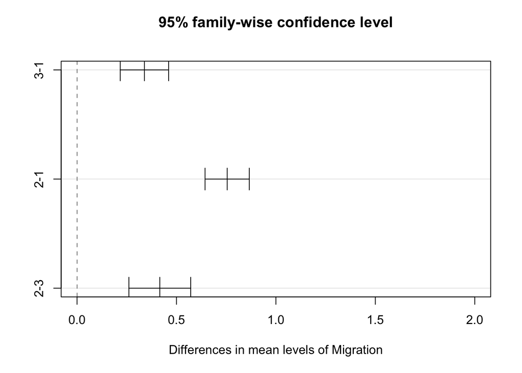

```r
# plotting the posthoc Tukey test for a nice visual summary
plot(posthoc_mm_a, xlim = c(0, 2)) # xlim set to show zero
```

### Step 4

Use a permutation approach to inference to generate a null distribution of F statistic values for the model of log(**Mass**) in relation to **Trophic.Level**. You can do this either by programming your own permutation test (e.g., by shuffling values for the predictor or response variable among observations and calculating an F statistic for each replicate) or by using the {infer} workflow and setting `calculate(stat="F")`.

```r
# pulling out the F-statistic (nonparametric)
og_F <- aov(logMass ~ Trophic.Level, data = d) %>% # original F-stat
  tidy() %>%
  filter(term == "Trophic.Level")
og_F # results for the F stat and p-value for the omnibus F test
```

```
## # A tibble: 1 × 6
##   term             df sumsq meansq statistic  p.value
##   <chr>         <dbl> <dbl>  <dbl>     <dbl>    <dbl>
## 1 Trophic.Level     3  559.   186.      79.1 1.26e-50
```

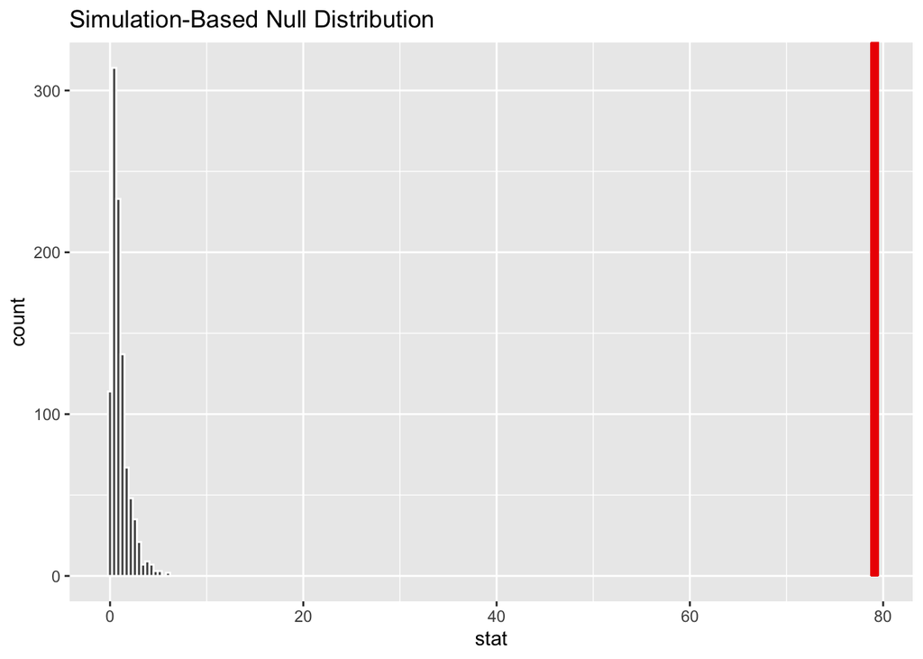

```r
# Could also do this as a loop
perm_F <- d %>%
  specify(logMass ~ Trophic.Level) %>%
  hypothesise(null = "independence") %>% # independence must be lowercase
  generate(reps = 1000, # 1000 reps
           type = "permute") %>% # permutation
  calculate(stat = "F") # calc F-stat in permutation
visualise(perm_F) + shade_p_value(obs_stat = og_F$statistic, direction = "greater") # or histogram
```

```r
# P-value Comparison
p_value <- perm_F %>% get_p_value(obs_stat = og_F$statistic, direction = "greater")
og_F$p.value
```

[output not shown]

```
## [1] 1.264878e-50
```

the end of challenge 1.